# Solutions to Hadley Wickham’s ggplot2: Elegant graphics for Data Analysis 2nd ed.

# 2.4.1 Exercises

1. Experiment with the colour, shape and size aesthetics. What happens when you map them to continuous values? What about categorical values? What happens when you use more than one aesthetic in a plot?

```r
summary(mpg)
```

```
##  manufacturer          model               displ            year
##  Length:234         Length:234         Min.   :1.600   Min.   :1999
##  Class :character   Class :character   1st Qu.:2.400   1st Qu.:1999
##  Mode  :character   Mode  :character   Median :3.300   Median :2004
##                                        Mean   :3.472   Mean   :2004
##                                        3rd Qu.:4.600   3rd Qu.:2008
##                                        Max.   :7.000   Max.   :2008
##       cyl           trans               drv                 cty
##  Min.   :4.000   Length:234         Length:234         Min.   : 9.00
##  1st Qu.:4.000   Class :character   Class :character   1st Qu.:14.00
##  Median :6.000   Mode  :character   Mode  :character   Median :17.00
##  Mean   :5.889                                         Mean   :16.86
##  3rd Qu.:8.000                                         3rd Qu.:19.00
##  Max.   :8.000                                         Max.   :35.00
##       hwy             fl               class
##  Min.   :12.00   Length:234         Length:234
##  1st Qu.:18.00   Class :character   Class :character
##  Median :24.00   Mode  :character   Mode  :character
##  Mean   :23.44
##  3rd Qu.:27.00
##  Max.   :44.00
```

we can see variables like cty,hwy,year are some continuous variables and model,trans,drv,class are categorical.

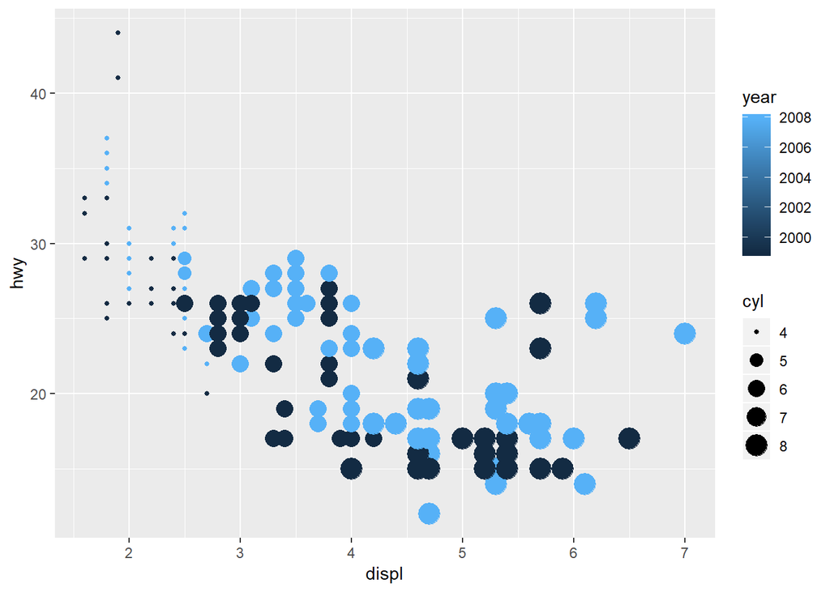

```r
#using a continuous variable you can see that the scale becomes non-discrete.Adding multiple values in aes will give us more than one aesthetic liek color as well as size in the below plot.
ggplot(mpg,aes(displ,hwy,color = year,size = cyl)) +
  geom_point()
```

2. What happens if you map a continuous variable to shape? Why? What happens if you map trans to shape? Why?

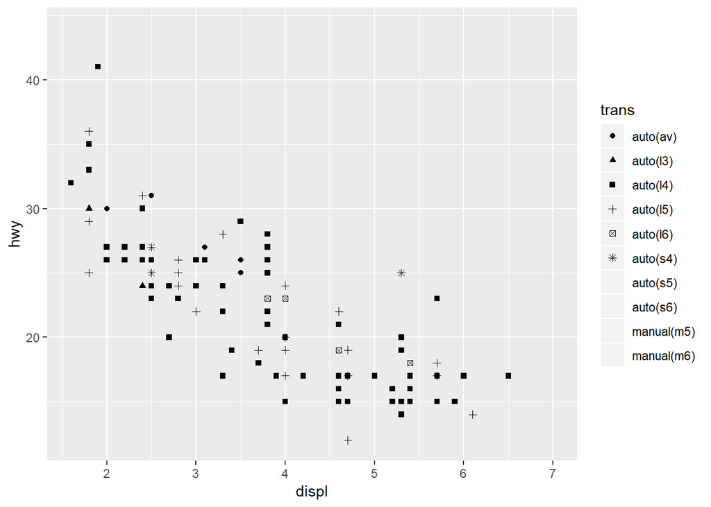

```r
ggplot(mpg,aes(displ,hwy,shape = trans)) +
  geom_point()
```

The shape aesthetic cannot accept more than 6 discrete values. Any more than 6 are not displayed and the points are removed from the scatter plot. No continuous variable is accepted by the shape parameter.

3.How is drive train related to fuel economy? How is drive train related to engine size and class?

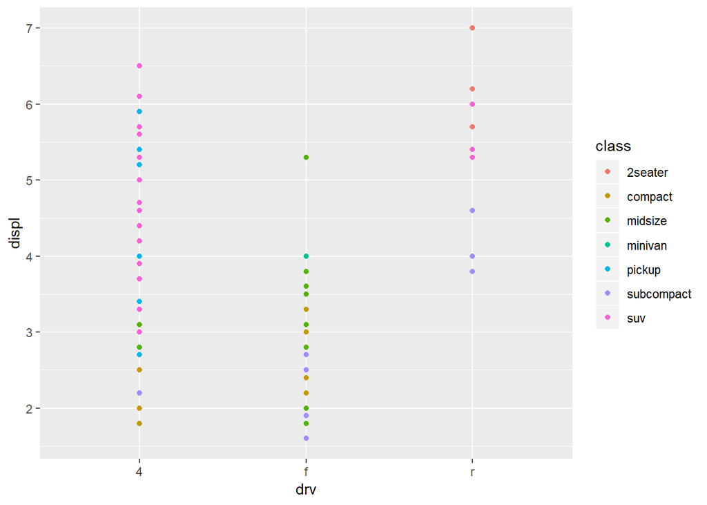

```r
#drive train with engine displacement and added color using class.
ggplot(mpg,aes(drv,displ,color = class)) +
  geom_point()
```

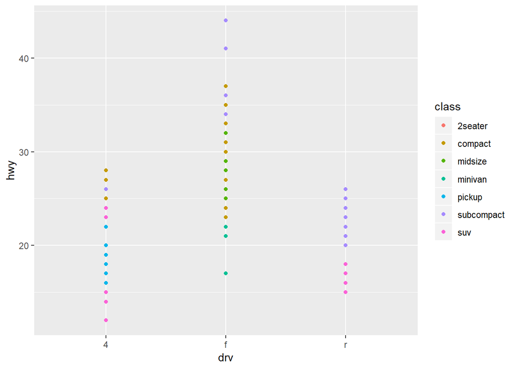

```r
#drive train with fuel economy
ggplot(mpg,aes(drv,hwy,color = class)) +
  geom_point()
```

# 2.5.1